# langley1_OriginalHomeworkCode_04

# HW 4: “What’s your Malfunction?”

Loading in the Kamilar and Cooper Dataset

```r
library(curl)
KC <- curl("https://raw.githubusercontent.com/fuzzyatelin/fuzzyatelin.github.io/master/AN597_Fall19/KamilarAndCooperData.csv")
KC <- read.csv(KC, header = TRUE, sep = ",", stringsAsFactors = FALSE)
head(KC)
```

```
##               Scientific_Name          Family          Genus      Species
## 1 Allenopithecus_nigroviridis Cercopithecidae Allenopithecus nigroviridis
## 2         Allocebus_trichotis Cercopithecidae      Allocebus    trichotis
## 3           Alouatta_belzebul        Atelidae       Alouatta     belzebul
## 4             Alouatta_caraya        Atelidae       Alouatta       caraya
## 5            Alouatta_guariba        Atelidae       Alouatta      guariba
## 6           Alouatta_palliata        Atelidae       Alouatta     palliata
##   Brain_Size_Species_Mean Brain_Size_Female_Mean   Brain_size_Ref
## 1                   58.02                  53.70 Isler et al 2008
## 2                      NA                     NA
## 3                   52.84                  51.19 Isler et al 2008
## 4                   52.63                  47.80 Isler et al 2008
## 5                   51.70                  49.08 Isler et al 2008
## 6                   49.88                  48.04 Isler et al 2008
##   Body_mass_male_mean Body_mass_female_mean Mass_Dimorphism
```

[output cut: 69 more lines]

```r
names(KC)
```

```
##  [1] "Scientific_Name"         "Family"
##  [3] "Genus"                   "Species"
##  [5] "Brain_Size_Species_Mean" "Brain_Size_Female_Mean"
##  [7] "Brain_size_Ref"          "Body_mass_male_mean"
##  [9] "Body_mass_female_mean"   "Mass_Dimorphism"
## [11] "Mass_Ref"                "MeanGroupSize"
## [13] "AdultMales"              "AdultFemale"
## [15] "AdultSexRatio"           "Social_Organization_Ref"
## [17] "InterbirthInterval_d"    "Gestation"
## [19] "WeaningAge_d"            "MaxLongevity_m"
## [21] "LitterSz"                "Life_History_Ref"
## [23] "GR_MidRangeLat_dd"       "Precip_Mean_mm"
## [25] "Temp_Mean_degC"          "AET_Mean_mm"
## [27] "PET_Mean_mm"             "Climate_Ref"
## [29] "HomeRange_km2"           "HomeRangeRef"
## [31] "DayLength_km"            "DayLengthRef"
## [33] "Territoriality"          "Fruit"
## [35] "Leaves"                  "Fauna"
## [37] "DietRef1"                "Canine_Dimorphism"
## [39] "Canine_Dimorphism_Ref"   "Feed"
## [41] "Move"                    "Rest"
## [43] "Social"                  "Activity_Budget_Ref"
```

Assigning variables to the Data columns I want to look at

```r
max_l<- KC$MaxLongevity_m
max_l
```

```
##   [1] 276.00     NA     NA 243.60     NA 300.00 240.00 300.00 360.00     NA
##  [11] 405.60     NA     NA 303.60 265.20 156.00 336.00 552.00 327.60 453.60
##  [21]     NA     NA     NA 492.00 324.00 216.00 300.00     NA 303.60     NA
##  [31]     NA 214.80 201.60     NA 211.20 180.00 201.60 240.00 184.80 181.20
##  [41] 528.00 541.20 657.60 492.00     NA 372.00 252.00 360.00 321.60     NA
##  [51] 339.60 396.00 276.00 447.60     NA 343.20 192.00 325.20 360.00 315.60
##  [61] 276.00 228.00 289.20 312.00     NA     NA 180.00 231.60 235.20 369.60
##  [71]     NA     NA 423.60 294.00 366.00     NA     NA 291.60 286.80     NA
##  [81]     NA     NA 220.80 444.00 360.00 360.00 240.00     NA     NA 180.00
##  [91]     NA 198.00 204.00 168.00     NA     NA 648.00     NA 205.20     NA
## [101] 144.00 528.00 444.00 480.00 540.00 684.00 432.00     NA 360.00 360.00
## [111] 255.60 214.80 297.60     NA     NA 103.00     NA 144.00     NA 392.40
## [121] 321.60     NA 196.80 350.40 376.80     NA 456.00 396.00     NA 432.00
## [131] 411.60 408.00 348.00 360.00 480.00 420.00 264.00     NA 400.80 555.96
## [141] 186.00     NA 144.00 370.80 183.60 252.00 529.20     NA     NA     NA
## [151] 318.00 205.20 225.60 204.00 576.00 720.00 302.40 540.00 450.00 540.00
## [161] 312.00 144.00     NA     NA     NA     NA     NA     NA 248.40     NA
## [171] 720.00     NA 192.00     NA     NA     NA     NA     NA 240.00 247.20
## [181] 300.00     NA     NA 354.00 228.00 294.00 246.00 242.40 182.40 184.80
## [191] 240.00     NA 277.20     NA 363.60     NA 324.00 300.00 456.00 144.00
## [201]     NA 180.00 336.00 373.20 373.20     NA 408.00 300.00 339.60 302.40
## [211] 276.00     NA 384.00
```

```r
mean_bs<- KC$Brain_Size_Species_Mean
mean_bs
```

```
##   [1]  58.02     NA  52.84  52.63  51.70  49.88  51.13  55.22  20.67     NA
##  [11]  16.30     NA     NA  16.85     NA   6.92 117.02 114.24 105.09 103.85
##  [21]   9.86   7.95 116.72 110.68  76.00  68.77     NA     NA     NA     NA
##  [31]     NA  11.43   7.95     NA     NA     NA   7.24     NA   7.32   4.17
##  [41]  65.45  66.63  72.93  69.84  66.09 116.43  99.07 105.99  94.68  70.10
##  [51]  59.58  57.39  65.26  62.61  65.40  65.90  74.20  71.33  61.84  65.97
##  [61]  71.13  55.08  59.56     NA     NA  61.45   5.81   2.60  48.33  65.00
##  [71]  62.58  64.91  77.70  74.39  73.83  74.90  73.07  44.85  97.73  21.45
##  [81]  22.10     NA  20.65  25.77  24.51  20.17  26.23  25.40     NA   5.53
##  [91]   4.62   3.71   3.96   2.65   3.51 491.27 490.41     NA  14.09  13.80
## [101]     NA  91.16  87.99 101.87     NA  85.13  84.69  34.81  96.50  22.90
## [111]  11.84     NA  12.83   6.70   7.25   6.87     NA     NA   8.25  93.97
## [121] 101.59   6.34   5.87 100.70  90.46  82.00  63.98 102.92  85.60  88.98
## [131] 105.59  94.90     NA  74.87  85.00  69.70  93.20     NA 148.00 153.88
## [141]   1.63     NA   1.72  37.35   5.80  92.30     NA 119.38     NA  13.49
## [151]  10.13     NA  11.78  11.50 341.29 368.35 167.42 163.19 146.17 178.00
## [161]  12.42   6.68  63.59  57.25     NA     NA  70.95     NA  32.26 389.50
## [171] 377.38  80.30  64.85  52.60  30.19  30.15  39.80  39.49     NA  26.21
## [181]  91.41     NA     NA 117.76     NA   7.94  10.14     NA   9.70   9.78
## [191]  11.09   9.48   9.76     NA     NA  25.07  24.14 110.93 123.50   3.16
## [201]     NA   3.36 133.33     NA  57.86  81.30  84.60  62.12  72.84 103.64
## [211]  61.29  31.08  32.12
```

### Part 1: Write a simple R function, Z.prop.test(), that can perform one- or two-sample Z-tests for proportion data

I put my function in #s so that my Rmd would knit (it wouldn’t knit otherwise because there are errors in my function)

```r
#z.prop.test<- function(p1, p0, n1, n2=NULL, p2=NULL, a=0.05, alternative = "two.sided", norm.distri.1 = "TRUE", norm.distri.2 = "TRUE", conf.level=0.95)
#{
#    q<- 1-p1
#    z.one.samp<- (p1 - p0)/(sqrt(p1 * q/ n1)) #The formula for a one sampled test
#    z.two.samp<- ((p1 - p2) - 0)/(sqrt(sd(p1)^2/n1)+(sd(p2)^2/n2)) #The formula for a two sampled       test
#    z = qnorm(1-a/2) #needed for my confidence interval formula
#    conf.int<- p1 + c(-1,1)*z*sqrt(p1*(1-p1)/n)
#    m.p1<- mean(p1) #calculating mean to use for my p-value
#    s.p1<- sd(p1) #sd to use for my p-value
#    z <- (m.p1-p1)/(s.p1/sqrt(n1)) #first part of equation for p-value
#    p.value<- 2*pnorm(-abs(z)) #to find p-value
#    if (alternative == "two.sided"){
#        return(z.one.samp)
#    }
#    else if (alternative == "less" & p2 != "NULL" &n2 != "NULL"){
#        return(z.two.samp) #should this p1 and p2 be means??
#    }
#    else if (alternative == "greater" & p2 != "NULL" &n2 != "NULL"){
#        return(z.two.samp)
#    }
#    if (conf.level == 0.95){
#        return(conf.int)
#    }
#    if (n1*p1 >5 & n1*(1-p1) >5 & p2 == "NULL" & n2 == "NULL"){
#        return(z.one.samp)
#    }
#    if (n1*p1 >5 & n1*(1-p1) >5 & p2 != "NULL" & n2 != "NULL"){
#        return(z.two.samp)
#    }
#    if(n1*p1 < 5 & n1*(1-p1) < 5){
#        return(warning("normal distribution violated")) #I can't get this warning to work...
#    }
#    multi_return <- function() {
#    my_list <- list("Z1" = z.one.samp, "Z2" = z.two.samp, "p-value" = p, "CI" = conf.intsize)
#    return(my_list)
#    }
#}


#TEST<- z.prop.test(p1=0.70, p0=.50, n1=100)
#TEST
#Test2<- z.prop.test(p1=0.70, p0=0.50, n1=100, n2=500, p2=0.30, alternative = "less", conf.level = 0.95)
#Test2 #Got an "NA" for this one...
#Test3<- z.prop.test(p1=0.70, p0=0.50, n1=2) #setting my valules to purposefully violate the normal distribution in order to try to get the warning message, but it doesn't work!!
#Test3
```

### Part 2: Longevity and Brain Size Linear Regression

#### Question 1: Fit the regression model and, using {ggplot2}, produce a scatterplot with the fitted line superimposed upon the data. Append the the fitted model equation to your plot

Fitting these variables to a linear regression

```r
lm1<- lm(data=KC, max_l ~ mean_bs)
lm1
```

```
##
## Call:
## lm(formula = max_l ~ mean_bs, data = KC)
##
## Coefficients:
## (Intercept)      mean_bs
##     248.952        1.218
```

```r
head(lm1$model)
```

```
##   max_l mean_bs
## 1 276.0   58.02
## 4 243.6   52.63
## 6 300.0   49.88
## 7 240.0   51.13
## 8 300.0   55.22
## 9 360.0   20.67
```

```r
summary(lm1)
```

```
##
## Call:
## lm(formula = max_l ~ mean_bs, data = KC)
##
## Residuals:
##     Min      1Q  Median      3Q     Max
## -198.27  -61.92  -17.78   56.16  331.36
##
## Coefficients:
##             Estimate Std. Error t value Pr(>|t|)
## (Intercept) 248.9523    11.1111   22.41   <2e-16 ***
## mean_bs       1.2180     0.1101   11.06   <2e-16 ***
## ---
## Signif. codes:  0 '***' 0.001 '**' 0.01 '*' 0.05 '.' 0.1 ' ' 1
##
## Residual standard error: 90.91 on 126 degrees of freedom
##   (85 observations deleted due to missingness)
## Multiple R-squared:  0.4928, Adjusted R-squared:  0.4887
## F-statistic: 122.4 on 1 and 126 DF,  p-value: < 2.2e-16
```

Using ggplot to create a scatterplot with fitted line and lm equation

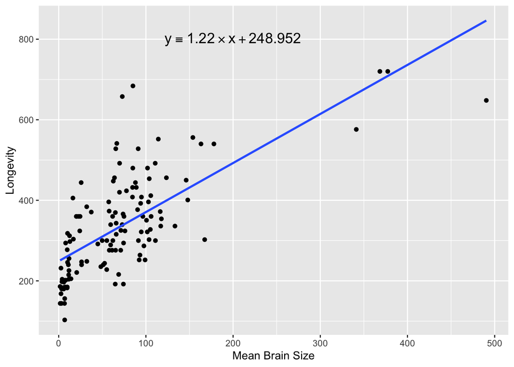

```r
library(ggplot2)

##This is version 1: I just manually type in the equation using the label() function on line 125
plot1 <- ggplot(data = KC, aes(x = mean_bs, y = max_l))
plot1 <- plot1 + labs(x= "Mean Brain Size", y= "Longevity")
plot1 <- plot1 + geom_point()
plot1 <- plot1 + geom_smooth(method = "lm", formula = y ~ x, se=FALSE) #geom_smooth puts in 95% confidence intervals automatically into the graph, by setting se = F, you can remove these CI (I'm removing them because the question doesn't specfically ask for them)
plot1 <- plot1 + geom_text(aes(label = "y%==%1.22%*%x + 248.952", x=200, y=800), parse = TRUE, check_overlap = TRUE, size= 5) #I used ?plotmath to see the appropriate syntax to use in order to write out the equation in the label() function
plot1
```

```r
##This is version 2: I'm trying package "basicTrendline" to add in the equation for me
library(basicTrendline)

#plot1 <- ggplot(data = KC, aes(x = mean_bs, y = max_l))
#plot1 <- plot1 + labs(x= "Mean Brain Size", y= "Longevity")
#plot1 <- plot1 + geom_point()
#plot1 <- plot1 + geom_smooth(method = "lm", formula = y ~ x, se=FALSE) #geom_smooth puts in 95% confidence intervals automatically into the graph, by setting se = F, you can remove these CI
#plot1 <- plot1 + trendline(mean_bs, max_l, model = "line2P", show.equation = TRUE, linecolor = "red", CI.level = 0.90, CI.fill= TRUE, show.Rpvalue = FALSE)
#plot1

#This version didn't work properly and kept giving me errors, I've put #s so that I can knit it but keep the code as reference
```

Now doing it over again for log(longevity) and log(brain size)

```r
lm2<- lm(data=KC, log(max_l) ~ log(mean_bs))
lm2
```

```
##
## Call:
## lm(formula = log(max_l) ~ log(mean_bs), data = KC)
##
## Coefficients:
##  (Intercept)  log(mean_bs)
##       4.8790        0.2341
```

```r
head(lm2$model)
```

```
##   log(max_l) log(mean_bs)
## 1   5.620401     4.060788
## 4   5.495528     3.963286
## 6   5.703782     3.909620
## 7   5.480639     3.934371
## 8   5.703782     4.011325
## 9   5.886104     3.028683
```

```r
summary(lm2)
```

```
##
## Call:
## lm(formula = log(max_l) ~ log(mean_bs), data = KC)
##
## Residuals:
##     Min      1Q  Median      3Q     Max
## -0.6955 -0.1750 -0.0097  0.1788  0.6084
##
## Coefficients:
##              Estimate Std. Error t value Pr(>|t|)
## (Intercept)   4.87895    0.06907   70.63   <2e-16 ***
## log(mean_bs)  0.23415    0.01781   13.15   <2e-16 ***
## ---
## Signif. codes:  0 '***' 0.001 '**' 0.01 '*' 0.05 '.' 0.1 ' ' 1
##
## Residual standard error: 0.2485 on 126 degrees of freedom
##   (85 observations deleted due to missingness)
## Multiple R-squared:  0.5784, Adjusted R-squared:  0.5751
## F-statistic: 172.9 on 1 and 126 DF,  p-value: < 2.2e-16
```

Scatterplot with equation for log LR

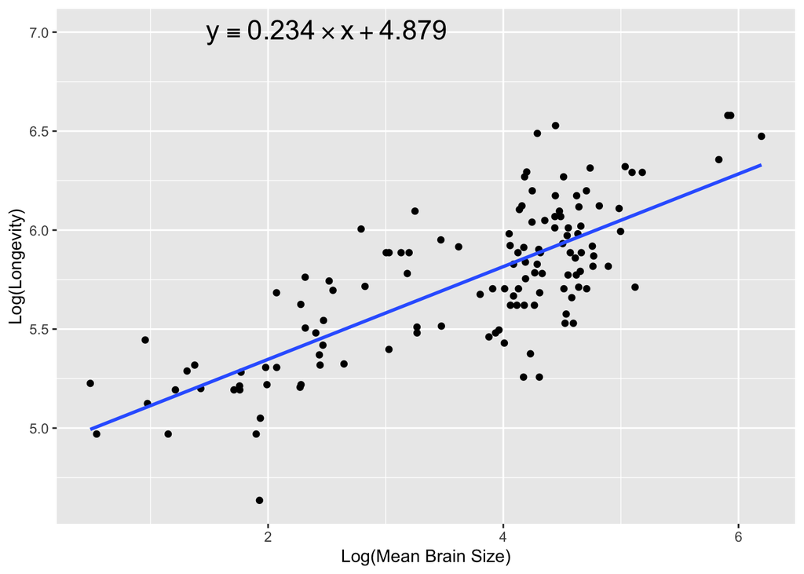

```r
##This is version 1: I just manually type in the equation using the label() function on line 125
plot2 <- ggplot(data = KC, aes(x = log(mean_bs), y = log(max_l)))
plot2 <- plot2 + labs(x= "Log(Mean Brain Size)", y= "Log(Longevity)")
plot2 <- plot2 + geom_point()
plot2 <- plot2 + geom_smooth(method = "lm", formula = y ~ x, se = FALSE) #geom_smooth puts in 95% confidence intervals automatically into the graph, by setting se = F, you can remove these CI
plot2 <- plot2 + geom_text(aes(label = "y%==%0.234%*%x + 4.879", x=2.5, y=7), parse = TRUE, check_overlap = TRUE, size= 6)
plot2
```

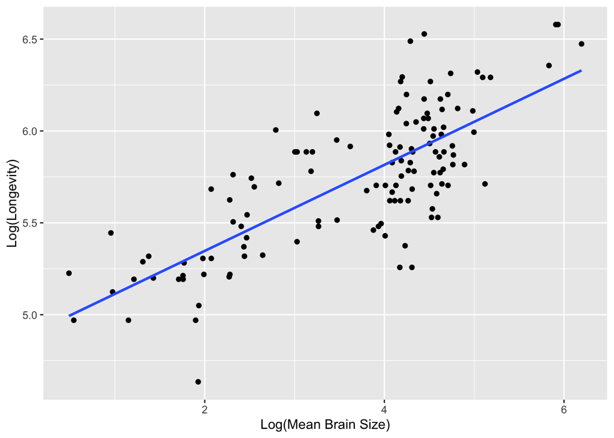

```r
##This is version 2: I'm trying package "basicTrendline" to add in the equation for me
plot2 <- ggplot(data = KC, aes(x = log(mean_bs), y = log(max_l)))
plot2 <- plot2 + labs(x= "Log(Mean Brain Size)", y= "Log(Longevity)")
plot2 <- plot2 + geom_point()
plot2 <- plot2 + geom_smooth(method = "lm", formula = y ~ x, se = FALSE) #geom_smooth puts in 95% confidence intervals automatically into the graph, by setting se = F, you can remove these CI
plot2
```

#### Question 2: Identify and interpret the point estimate of the slope (β1), as well as the outcome of the test associated with the hypotheses H0: β1 = 0; HA: β1 ≠ 0. Also, find a 90 percent CI for the slope (β1) parameter.

The point estimate of the slope

```r
summary(lm1)
```

```
##
## Call:
## lm(formula = max_l ~ mean_bs, data = KC)
##
## Residuals:
##     Min      1Q  Median      3Q     Max
## -198.27  -61.92  -17.78   56.16  331.36
##
## Coefficients:
##             Estimate Std. Error t value Pr(>|t|)
## (Intercept) 248.9523    11.1111   22.41   <2e-16 ***
## mean_bs       1.2180     0.1101   11.06   <2e-16 ***
## ---
## Signif. codes:  0 '***' 0.001 '**' 0.01 '*' 0.05 '.' 0.1 ' ' 1
##
## Residual standard error: 90.91 on 126 degrees of freedom
##   (85 observations deleted due to missingness)
## Multiple R-squared:  0.4928, Adjusted R-squared:  0.4887
## F-statistic: 122.4 on 1 and 126 DF,  p-value: < 2.2e-16
```

```r
#slope = 1.2180
# intercept = #248.952

#My interpretation: for every added month to someone's life, their brain size is 1.218 grams bigger on average; 248.952 months of the average person's life doesn't depend on their mean brain size (?)

#H0: β1 = 0 --> x= 0, y= 248.952
#HA: β1 ≠ 0 --> what we see when we plot the linear regression??

lm1_ci<- confint(lm1, level = 0.90)
lm1_ci #CI for slope= 1.035571, 1.40041
```

```
##                    5 %      95 %
## (Intercept) 230.540738 267.36379
## mean_bs       1.035571   1.40041
```

For the log linear regression

```r
summary(lm2)
```

```
##
## Call:
## lm(formula = log(max_l) ~ log(mean_bs), data = KC)
##
## Residuals:
##     Min      1Q  Median      3Q     Max
## -0.6955 -0.1750 -0.0097  0.1788  0.6084
##
## Coefficients:
##              Estimate Std. Error t value Pr(>|t|)
## (Intercept)   4.87895    0.06907   70.63   <2e-16 ***
## log(mean_bs)  0.23415    0.01781   13.15   <2e-16 ***
## ---
## Signif. codes:  0 '***' 0.001 '**' 0.01 '*' 0.05 '.' 0.1 ' ' 1
##
## Residual standard error: 0.2485 on 126 degrees of freedom
##   (85 observations deleted due to missingness)
## Multiple R-squared:  0.5784, Adjusted R-squared:  0.5751
## F-statistic: 172.9 on 1 and 126 DF,  p-value: < 2.2e-16
```

```r
#slope = 0.23415
#intercepts = 4.87895

lm2_ci<- confint(lm2, level = 0.90)
lm2_ci #CI for slope= 0.2046, 0.2637
```

```
##                    5 %      95 %
## (Intercept)  4.7644934 4.9934084
## log(mean_bs) 0.2046396 0.2636595
```

#### Question 3: Using your model, add lines for the 90 percent confidence and prediction interval bands on the plot and add a legend to differentiate between the lines.

```r
lm1_pi <- predict(lm1, newdata = data.frame(mean_bs = KC$Brain_Size_Species_Mean), interval = "prediction", level = 0.90)  #for a vector of mean_bs values
head(lm1_pi)
```

```
##        fit      lwr      upr
## 1 319.6201 168.3750 470.8651
## 2       NA       NA       NA
## 3 313.3109 162.0496 464.5722
## 4 313.0551 161.7930 464.3172
## 5 311.9224 160.6567 463.1880
## 6 309.7056 158.4324 460.9789
```

```r
nrow(lm1_pi)
```

```
## [1] 213
```

```r
nrow(KC) #checking the number of rows in these to make sure they're the same, the cbind() in my next line won't work if they have different number of rows
```

```
## [1] 213
```

```r
new_df<- cbind(KC, lm1_pi) #binding my main data object KC with my new lm1_pi variable
head(new_df)
```

```
##               Scientific_Name          Family          Genus      Species
## 1 Allenopithecus_nigroviridis Cercopithecidae Allenopithecus nigroviridis
## 2         Allocebus_trichotis Cercopithecidae      Allocebus    trichotis
## 3           Alouatta_belzebul        Atelidae       Alouatta     belzebul
## 4             Alouatta_caraya        Atelidae       Alouatta       caraya
## 5            Alouatta_guariba        Atelidae       Alouatta      guariba
## 6           Alouatta_palliata        Atelidae       Alouatta     palliata
##   Brain_Size_Species_Mean Brain_Size_Female_Mean   Brain_size_Ref
## 1                   58.02                  53.70 Isler et al 2008
## 2                      NA                     NA
## 3                   52.84                  51.19 Isler et al 2008
## 4                   52.63                  47.80 Isler et al 2008
## 5                   51.70                  49.08 Isler et al 2008
## 6                   49.88                  48.04 Isler et al 2008
##   Body_mass_male_mean Body_mass_female_mean Mass_Dimorphism
```

[output cut: 76 more lines]

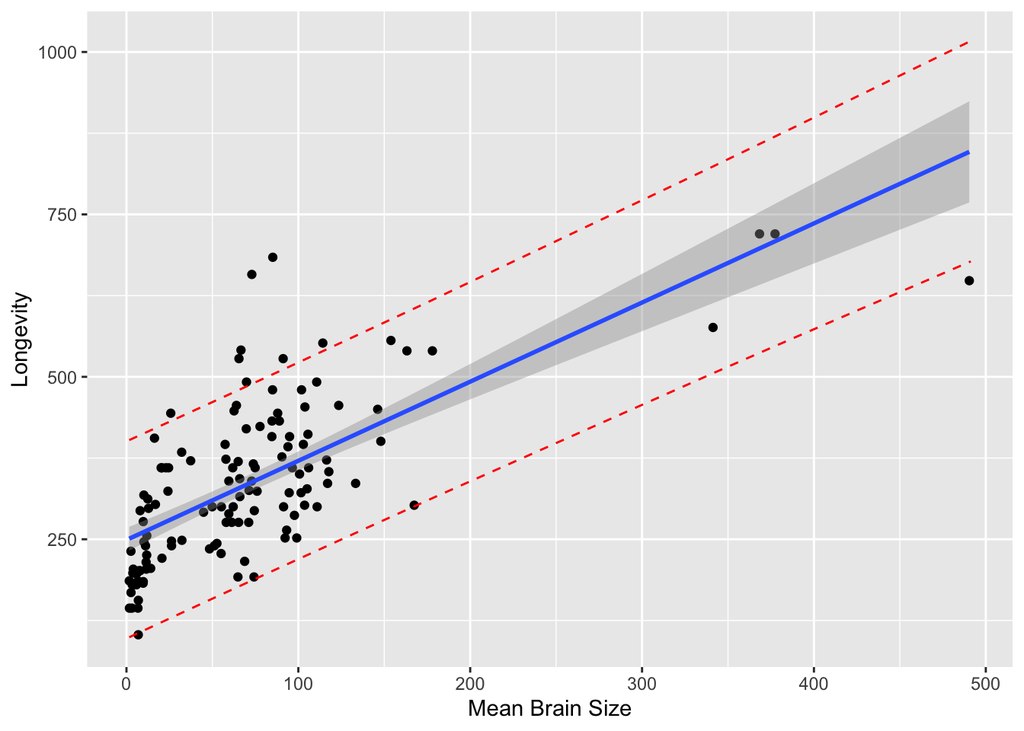

```r
plot3<- ggplot(new_df, aes(mean_bs, max_l))+
    geom_point() +
    labs(x= "Mean Brain Size", y= "Longevity") +
    geom_line(aes(y=lwr), color = "red", linetype = "dashed")+
    geom_line(aes(y=upr), color = "red", linetype = "dashed")+
    geom_smooth(method=lm, level = 0.90)+ #geom_smooth automatically puts in 95% CI so I need to change it to 90%
    theme(legend.position = c(0.95, 0.95)) #hmm there still is no legend...
plot3
```

```r
#leg.text<- c("90% PI", "90% CI") #trying out the legend() function to see if it will add in the legend for me
#plot3(legend(list(x=200, y=800), legend = leg.text, col = 2:3, pch = 1:2, lty = 1)) #UGH this also doesn't work...
```

Now doing it for my log linear regression

```r
lm2_pi <- predict(lm2, newdata = data.frame(mean_bs = KC$Brain_Size_Species_Mean), interval = "prediction", level = 0.90)  # for a vector of mean_bs values
head(lm2_pi)
```

```
##        fit      lwr      upr
## 1 5.829783 5.416322 6.243243
## 2       NA       NA       NA
## 3 5.807885 5.394491 6.221279
## 4 5.806953 5.393561 6.220344
## 5 5.802778 5.389397 6.216159
## 6 5.794387 5.381024 6.207749
```

```r
nrow(lm2_pi)
```

```
## [1] 213
```

```r
nrow(KC) #checking the number of rows in these to make sure they're the same, the cbind() in my next line won't work if they have different number of rows
```

```
## [1] 213
```

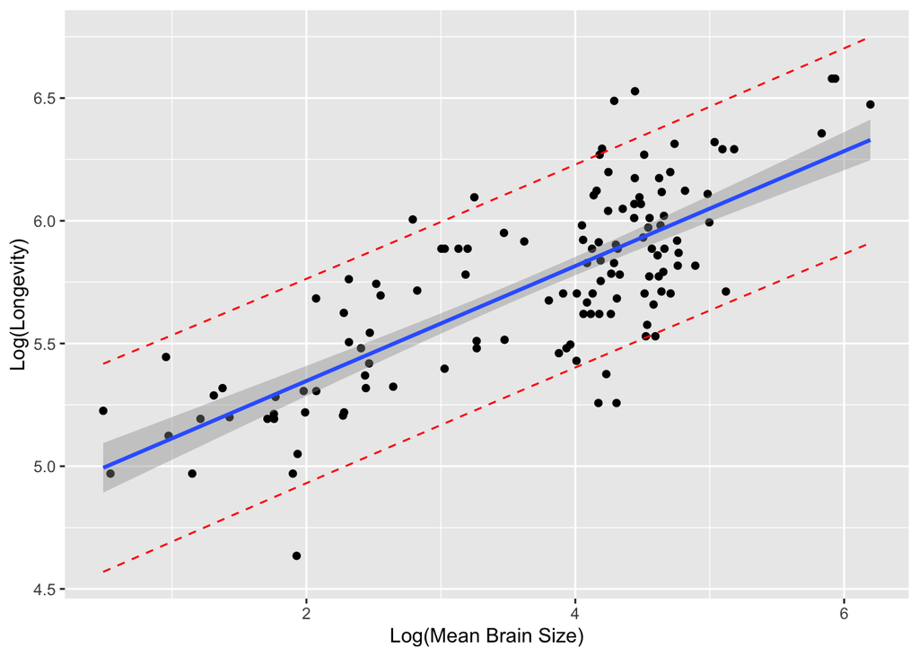

```r
new_df_log<- cbind(KC, lm2_pi) #binding my main data object KC with my new lm1_pi variable

plot4<- ggplot(new_df_log, aes(log(mean_bs), log(max_l)))+
    geom_point()+
    labs(x= "Log(Mean Brain Size)", y= "Log(Longevity)") +
    geom_line(aes(y=lwr), color = "red", linetype = "dashed")+
    geom_line(aes(y=upr), color = "red", linetype = "dashed")+
    geom_smooth(method=lm, level = 0.90) #geom_smooth automatically puts in 95% CI so I need to change it to 90%
plot4
```

#### Question 4: Produce a point estimate and associated 90 percent PI for the longevity of a species whose brain weight is 800 gm. Do you trust the model to predict observations accurately for this value of the explanatory variable? Why or why not?

```r
new.dat <- data.frame(mean_bs=800)
predict(lm1, newdata = new.dat, interval = 'predict', level = 0.90)
```

```
##        fit      lwr      upr
## 1 1223.345 1021.805 1424.884
```

```r
#point estimate = 1223.345
#lower/upper = 1021.805, 1424.884

#The prediction intervals are always going to be wider than the confidence intervals. They are predicting the range for longevity when mean brain size = 800 grams. The value for longevity when brain size = 800 grams will fall in this range 90% of the time. When looking at the graph, you see most of the data falls between the 0-200 range for brain size so maybe a prediction for 800 gms will be more difficult because there is not as much data to base it on.
```

## My Challenges

- Part 1: My function doesn’t work properly. I think I have the right start but I’m stuck moving forward. Tricky!!
- Part 2, Question 1: Still not 100% confident with adding the equation to my plots. I tried the basicTrendline package, which you can see in my version two on lines 110 and 140.
- Part 2, Question 3: I can’t seem to figure out a way to add a legend to differentiate between prediction intervals and confidence intervals in the plots. Usually you can add one in when you categorize different variables from your data using the aes() function (i.e. breaking them up by color, age, etc.), which isn’t exactly the case for this so that’s probably why it’s not working